# Chapter 3 Is the community spatially structured?

Chapter 2 produced a community table. This chapter asks the question that makes the data worth collecting: **do nearby microsamples host more similar communities than distant ones?**

We will attack it with the standard microbial ecology toolkit — ordination, PERMANOVA, spatial autocorrelation — and that toolkit will mostly **fail**. Understanding *why* it fails is the point of this chapter, and the reason Chapter 4 needs a different method.

## 3.1 Putting the microsamples back on the tissue

The most direct thing to do with spatial data is look at it. Every microsample has a pixel position on the photograph of its cryosection, so any per-microsample number can be painted onto the tissue.

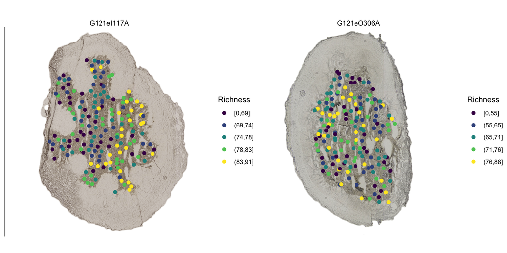

```r
plot_on_section("G121eI117A", sample_metadata, "richness",
                "Richness", pixel_coords, diverging = FALSE) +
plot_on_section("G121eO306A", sample_metadata, "richness",
                "Richness", pixel_coords, diverging = FALSE)
```

And the variable we ultimately care about — how far each microsample sits from the epithelium, the living gut wall:

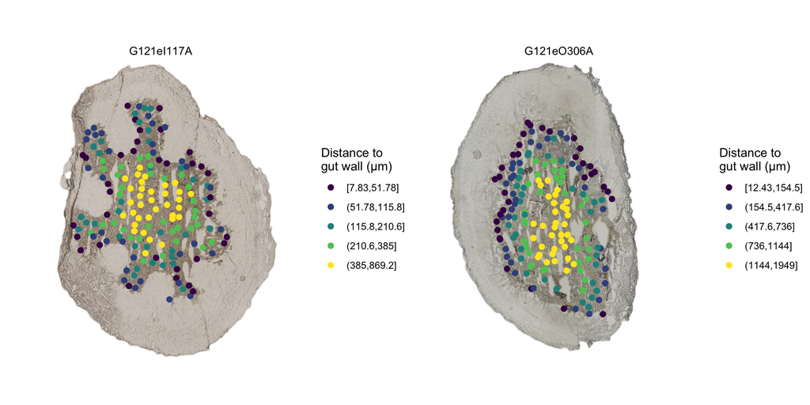

```r
plot_on_section("G121eI117A", sample_metadata, "distance_host",
                "Distance to\ngut wall (µm)", pixel_coords, diverging = FALSE) +
plot_on_section("G121eO306A", sample_metadata, "distance_host",
                "Distance to\ngut wall (µm)", pixel_coords, diverging = FALSE)
```

Distance to the wall varies smoothly across the section — it is a genuine spatial gradient, by construction. Richness looks patchier. Whether those patches mean anything is what the rest of the chapter tests.

## 3.2 Compositional data and the CLR transformation

We now have to separate two questions that the raw table mixes together: *how much* was in a microsample, and *what it was made of*.

The first is sequencing depth, which under this protocol carries biomass information (Chapter 2). We set it aside deliberately here and pick it up again as its own variable.

The second is composition, and it is genuinely compositional: within a microsample, only the ratios between genomes are interpretable. Euclidean distances on raw proportions are misleading, and the standard fix is the **centred log-ratio (CLR)** — divide every value by the geometric mean of its microsample, then take logs. Note what CLR does to the total: it divides it out entirely. That is the right move for asking *what lives here*, and it is exactly why the biomass signal has to be reintroduced separately later.

Logs need positive numbers, so zeros are replaced first, using a Bayesian estimator that respects the compositional structure.

```r
comm_all <- genome_counts %>%
  column_to_rownames("genome") %>%
  t() %>%
  as.data.frame()
comm_all <- comm_all[rowSums(comm_all) > 0, colSums(comm_all) > 0, drop = FALSE]

# zeros -> small positive values; genomes too sparse to estimate are dropped
comm_repl <- cmultRepl(comm_all, method = "GBM", output = "prop",
                       z.warning = 0.95)
```

```
No. adjusted imputations:  1569
```

```r
clr <- function(x) log(x) - rowMeans(log(x))
comm_clr <- clr(as.matrix(comm_repl))

dim(comm_clr)  # microsamples x genomes retained
```

```
[1] 324  89
```

Note how much shrank: from 223 genomes to under a hundred. Everything else was too sparse across these two cryosections to place on a log scale at all.

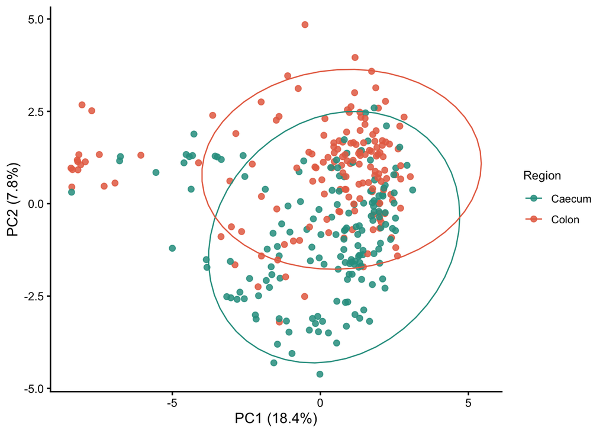

```r
pca <- prcomp(comm_clr, center = TRUE, scale. = FALSE)
var_pct <- round(100 * pca$sdev^2 / sum(pca$sdev^2), 1)

pca_scores <- as.data.frame(pca$x[, 1:2]) %>%
  rownames_to_column("microsample") %>%
  left_join(sample_metadata, by = "microsample")

ggplot(pca_scores, aes(PC1, PC2, colour = region)) +
  geom_point(size = 2, alpha = 0.85) +
  stat_ellipse(linewidth = 0.5) +
  scale_colour_manual(values = region_colors) +
  labs(x = paste0("PC1 (", var_pct[1], "%)"),
       y = paste0("PC2 (", var_pct[2], "%)"),
       colour = "Region")
```

The two organs overlap heavily. Let us quantify that with PERMANOVA, which asks whether a variable explains more between-sample distance than label shuffling would produce by chance.

```r
dist_clr <- dist(comm_clr, method = "euclidean")   # Aitchison distance

meta_ord <- sample_metadata %>%
  filter(microsample %in% rownames(comm_clr)) %>%
  arrange(match(microsample, rownames(comm_clr)))

adonis2(dist_clr ~ region, data = meta_ord, permutations = 999)
```

```
Permutation test for adonis under reduced model
Permutation: free
Number of permutations: 999

adonis2(formula = dist_clr ~ region, data = meta_ord, permutations = 999)
          Df SumOfSqs      R2      F Pr(>F)
Model      1    363.4 0.03142 10.447  0.001 ***
Residual 322  11201.1 0.96858
Total    323  11564.5 1.00000
---
Signif. codes:  0 '***' 0.001 '**' 0.01 '*' 0.05 '.' 0.1 ' ' 1
```

Caecum and colon differ significantly — but **R² is only about 3%**. Two different organs, and the difference between them accounts for a thirtieth of the variation in the data.

**First real result.** At this scale, variation *between neighbouring microsamples within one section* dwarfs the variation *between gut regions*. That is the whole justification for micro-scale sampling: homogenise a caecum and you average away 97% of what is actually going on.

## 3.3 Working within a single cryosection

If local variation is where the signal is, the analysis belongs inside one cryosection, where gut region, animal, and laboratory batch are all held constant and the only thing that varies is position.

`prepare_section()` does that: it pulls out one section, drops empty microsamples, and replaces zeros within that section alone.

```r
caecum <- prepare_section("G121eI117A", genome_counts, sample_metadata)
```

```
No. adjusted imputations:  457
```

```r
colon  <- prepare_section("G121eO306A", genome_counts, sample_metadata)
```

```
No. adjusted imputations:  1006
```

```r
tibble(
  section     = c(caecum$section, colon$section),
  microsamples = c(nrow(caecum$comm_red), nrow(colon$comm_red)),
  genomes      = c(ncol(caecum$comm_red), ncol(colon$comm_red))
)
```

```
# A tibble: 2 × 3
  section    microsamples genomes
  <chr>             <int>   <int>
1 G121eI117A          165      92
2 G121eO306A          159      87
```

Now the key test. Does distance to the gut wall explain community composition inside a single 2 mm section?

```r
caecum_clr  <- clr(as.matrix(caecum$comm_zero_repl))
caecum_dist <- dist(caecum_clr)
caecum_meta <- caecum$metadata

adonis2(caecum_dist ~ distance_host, data = caecum_meta, permutations = 999)
```

```
Permutation test for adonis under reduced model
Permutation: free
Number of permutations: 999

adonis2(formula = caecum_dist ~ distance_host, data = caecum_meta, permutations = 999)
          Df SumOfSqs      R2      F Pr(>F)
Model      1     47.2 0.00872 1.4335   0.09 .
Residual 163   5364.1 0.99128
Total    164   5411.3 1.00000
---
Signif. codes:  0 '***' 0.001 '**' 0.01 '*' 0.05 '.' 0.1 ' ' 1
```

**Not significant.** Now compare that with the coordinates themselves, and with sequencing depth — in both sections:

```r
colon_clr  <- clr(as.matrix(colon$comm_zero_repl))
colon_dist <- dist(colon_clr)
colon_meta <- colon$metadata

permanova_row <- function(dist_matrix, meta, rhs, label, section) {
  a <- adonis2(as.formula(paste("dist_matrix ~", rhs)),
               data = meta, permutations = 999)
  tibble(section = section, term = label,
         R2 = round(a$R2[1], 4), F = round(a$F[1], 2), p = a$`Pr(>F)`[1])
}

terms <- list(
  c("distance_host",                    "distance to gut wall"),
  c("Xcoord + Ycoord",                  "X + Y coordinates"),
  c("log(after_filtering.total_bases)", "log(sequencing depth)")
)

bind_rows(
  map_dfr(terms, ~ permanova_row(caecum_dist, caecum_meta, .x[1], .x[2], "caecum")),
  map_dfr(terms, ~ permanova_row(colon_dist,  colon_meta,  .x[1], .x[2], "colon"))
)
```

```
# A tibble: 6 × 5
  section term                      R2     F     p
  <chr>   <chr>                  <dbl> <dbl> <dbl>
1 caecum  distance to gut wall  0.0087  1.43 0.076
2 caecum  X + Y coordinates     0.0216  1.78 0.005
3 caecum  log(sequencing depth) 0.0508  8.73 0.001
4 colon   distance to gut wall  0.007   1.11 0.277
5 colon   X + Y coordinates     0.0169  1.34 0.096
6 colon   log(sequencing depth) 0.115  20.3  0.001
```

**Permutation p-values wobble.** PERMANOVA estimates significance by shuffling, so re-running the same test gives slightly different p-values (0.08 rather than 0.09, say). Read them as approximate, and never as a hard threshold.

In an equimolar-pooled study this would be a red flag: a technical variable driving composition means something went wrong. Here it is not. Depth stands in for biomass, and it is entirely reasonable that microsamples holding more bacteria hold a *different* community from microsamples holding very few. Dense and sparse patches of gut content are different habitats.

What the result does mean is that biomass, not position, is the leading axis of compositional variation inside a cryosection. Any spatial gradient we hope to find has to be looked for underneath it.

## 3.4 Spatial autocorrelation

To measure spatial structure directly we need a definition of “nearby”. Microsamples are not on a regular grid — the laser cuts where the tissue allows — so rather than pick a distance cutoff we build a **Gabriel graph**: two microsamples are joined when no third one lies inside the circle having them as its diameter.

```r
caecum_nb <- neighbour_graph(caecum_meta[, c("Xcoord", "Ycoord")])
caecum_nb
```

```
Neighbour list object:
Number of regions: 165
Number of nonzero links: 698
Percentage nonzero weights: 2.56382
Average number of links: 4.230303
```

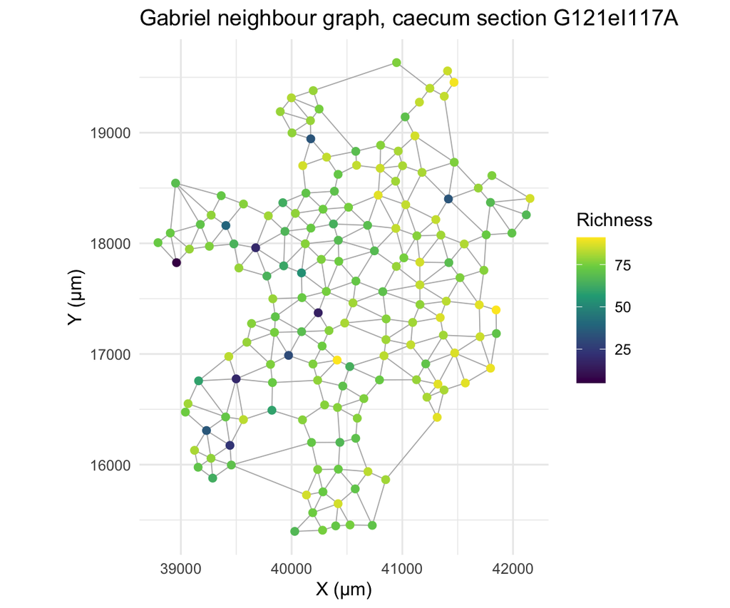

```r
plot_neighbour_graph(caecum_meta[, c("Xcoord", "Ycoord")], caecum_nb,
                     point_values = caecum_meta$richness,
                     value_label = "Richness") +
  labs(title = "Gabriel neighbour graph, caecum section G121eI117A")
```

**Moran’s I** is a correlation coefficient for space: it compares each microsample’s value with its neighbours’.

- **I > 0** — neighbours resemble each other (spatial structure)
- **I ≈ 0** — values arranged at random
- **I < 0** — neighbours systematically *unlike* each other

Computing it at increasing lag orders — direct neighbours, then neighbours-of-neighbours, and so on — shows how far the resemblance reaches.

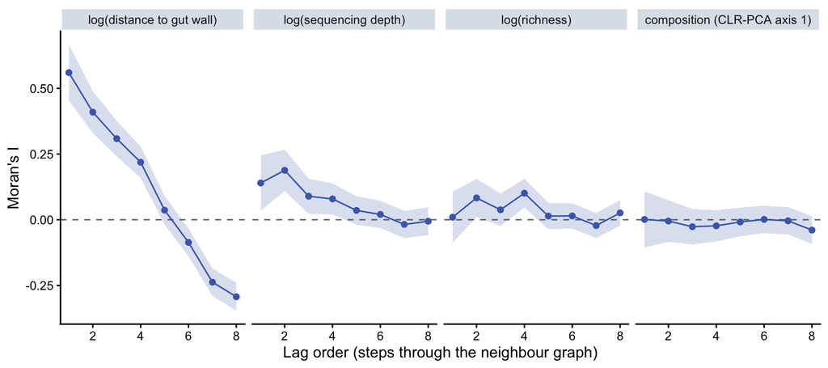

```r
correlograms <- bind_rows(
  moran_correlogram(caecum_nb, log(caecum_meta$distance_host)) %>%
    mutate(variable = "log(distance to gut wall)"),
  moran_correlogram(caecum_nb, log(caecum_meta$after_filtering.total_bases)) %>%
    mutate(variable = "log(sequencing depth)"),
  moran_correlogram(caecum_nb, log(caecum_meta$richness)) %>%
    mutate(variable = "log(richness)"),
  moran_correlogram(caecum_nb, prcomp(caecum_clr)$x[, 1]) %>%
    mutate(variable = "composition (CLR-PCA axis 1)")
) %>%
  mutate(variable = fct_inorder(variable))

ggplot(correlograms, aes(x = lag, y = morans_i)) +
  geom_hline(yintercept = 0, linetype = "dashed", colour = "grey50") +
  geom_ribbon(aes(ymin = lower, ymax = upper), fill = "#4a6ab7", alpha = 0.2) +
  geom_line(colour = "#4a6ab7") +
  geom_point(colour = "#4a6ab7", size = 1.8) +
  facet_wrap(~ variable, nrow = 1) +
  scale_x_continuous(breaks = seq(2, 8, 2)) +
  labs(x = "Lag order (steps through the neighbour graph)", y = "Moran's I")
```

Read the four panels in order:

1. **Distance to the gut wall** is strongly autocorrelated at short lags and turns negative at long ones — the signature of a gradient. This is guaranteed: it is a smooth function of position.
2. **Sequencing depth** is also autocorrelated, weakly but clearly (I = 0.14, p = 0.003). Read as biomass, this is a result in its own right: **microbial biomass is spatially patchy at the sub-millimetre scale.** Neighbouring pieces of tissue tend to be densely or sparsely colonised together.
3. **Richness** is essentially flat — despite correlating with depth at ρ > 0.9. Worth pausing on: two variables can be tightly correlated and still differ in spatial behaviour.
4. **Composition**, summarised as the first CLR-PCA axis, is **also flat**.

```r
lw <- nb2listw(caecum_nb)

map_dfr(
  list(
    "log(distance to gut wall)" = log(caecum_meta$distance_host),
    "log(sequencing depth)"     = log(caecum_meta$after_filtering.total_bases),
    "log(richness)"             = log(caecum_meta$richness),
    "composition (PCA axis 1)"  = prcomp(caecum_clr)$x[, 1]
  ),
  function(v) {
    tst <- moran.test(v, lw, zero.policy = TRUE)
    tibble(morans_i = round(unname(tst$estimate[1]), 3),
           p_value  = signif(tst$p.value, 3))
  },
  .id = "variable"
)
```

```
# A tibble: 4 × 3
  variable                  morans_i  p_value
  <chr>                        <dbl>    <dbl>
1 log(distance to gut wall)    0.56  1.22e-25
2 log(sequencing depth)        0.14  3.31e- 3
3 log(richness)                0.01  3.75e- 1
4 composition (PCA axis 1)     0.001 4.47e- 1
```

## 3.5 Why the obvious approach failed

By the standard toolkit, this dataset has **no spatial structure in community composition**. But that conclusion rests entirely on one choice we never examined: using PCA axis 1 as the summary of “what lives here”.

PCA ranks its axes by **variance**, not by relevance. Nothing guarantees that the largest axis is the interesting one. Look at what the first three axes actually correspond to:

```r
caecum_pca <- prcomp(caecum_clr)
caecum_var <- round(100 * caecum_pca$sdev^2 / sum(caecum_pca$sdev^2), 1)

map_dfr(1:3, function(k) {
  ax  <- caecum_pca$x[, k]
  tst <- moran.test(ax, lw, zero.policy = TRUE)
  tibble(
    axis            = paste0("PC", k),
    variance_pct    = caecum_var[k],
    rho_depth       = round(cor(ax, log(caecum_meta$after_filtering.total_bases),
                                method = "spearman"), 2),
    rho_host_dist   = round(cor(ax, log(caecum_meta$distance_host),
                                method = "spearman"), 2),
    morans_i        = round(unname(tst$estimate[1]), 3),
    moran_p         = signif(tst$p.value, 3)
  )
})
```

```
# A tibble: 3 × 6
  axis  variance_pct rho_depth rho_host_dist morans_i  moran_p
  <chr>        <dbl>     <dbl>         <dbl>    <dbl>    <dbl>
1 PC1           13.4     -0.14          0.1     0.001 0.447
2 PC2            8.2      0.77          0.02    0.184 0.000233
3 PC3            6.4      0.02          0.21    0.146 0.00231
```

Read that table carefully — it is the turning point of the practical.

- **PC1** is the biggest axis (13% of variance) and corresponds to **nothing we measured**: not depth, not position, and it is not spatially autocorrelated. It is unstructured microsample-to-microsample turnover — the stochastic part of who happens to be where.
- **PC2** is the biomass axis (ρ ≈ 0.8 with depth) and *is* spatially autocorrelated, consistent with the patchiness we saw above.
- **PC3** carries the weak trace of distance to the gut wall (ρ ≈ 0.2) and is also significantly autocorrelated.

**The gradient we came for is on axis 3.** It was never going to be found by looking at axis 1, and it is smeared thinly across several axes rather than isolated on any of them — because nothing in PCA’s objective function has any reason to isolate it.

**What we need instead** is a method that does not rank axes by size, but looks for the axis that is simultaneously **organised in space** and **associated with the kind of bacteria involved** — their metabolism and their evolutionary history. Sequencing noise cannot fake that combination: there is no reason for a microsample’s biomass to correlate with what its bacteria can metabolise. That is exactly what extended RLQ does, and it is the subject of Chapter 4.